# Static Score and Slope: A Comprehensive Validity Analysis of the of the quop-L2 Reading Progress Assessment

Mathis Erichsen

Juni 2020

# 1 Preparations

Conveniently install/load necessary packages.

```r
ipak <- function(pkg){
  new.pkg <- pkg[!(pkg %in% installed.packages()[, "Package"])]
  if (length(new.pkg))
    install.packages(new.pkg, dependencies = TRUE)
  sapply(pkg, require, character.only = TRUE)
}
packages <- c("haven", "chron", "lubridate", "psych", "cNORM", "formattable", "lavaan", "plyr", "naniar", "reshape2", "ggplot2", "Hmisc", "dplyr")
ipak(packages)
```

```
##       haven       chron   lubridate       psych       cNORM formattable
##        TRUE        TRUE        TRUE        TRUE        TRUE        TRUE
##      lavaan        plyr      naniar    reshape2     ggplot2       Hmisc
##        TRUE        TRUE        TRUE        TRUE        TRUE        TRUE
##       dplyr
##        TRUE
```

# 2 Read Data

SPSS data file containing quop data for 2nd-graders for 8 testing points (one school year), n=1989 subjects and pre and post (beginning and end of school year) standardized paper-pencil test data as well as teacher judgments of reading capabilities pre for a subsample of n=354 subjects.

Data overview:

- Quop t1-t8 (whole school year)
- Standardized Tests (pre and post, beginning and end of school year)
  - CFT (Intelligence) Pre
  - DEMAT (Mathematics) Pre
  - ELFE (Reading) Pre and Post
- Teacher Judgments of Reading Capability (rating and criterial judgment) Pre

The raw quop scores, teacher judgments and standardized test scores, as given in the file

00_data_unprepared.sav

were preprocessed (cleaning of the data and scale formation for the standardized test scores) in SPSS using the syntax given in the file

01_data_preparation_syntax.sps.

The output of this process was saved in the file

02_data_prepared.sav.

This file is now read into R.

(The read-in data is returned as a tibble by read_sav, so indexing works a bit differently leading to [problems](https://www.r-bloggers.com/the-trouble-with-tibbles/) down the path. Therefore transform the data into a regular dataframe.)

```r
#read data from SPSS format with haven-package
data = read_sav("data/02_data_prepared.sav")
#transform in regular dataframe (read_sav returns a tibble)
data <- as.data.frame(data)
```

# 3 Set Parameters

Define some parameters that are needed for data processing, such as how many items does a quop test consist of.

```r
#parameters for preprocessing
n_items <- 46
grade_check <- 2
age_check_lb <- 6
age_check_ub <- 12
time_pts <- c(1:8)

#word, sentence and text scale
scales <- c("w", "s", "t")
#quop items
items <- list(1:20, 21:33, 34:46)
#quop items separated into the three scales like this (g-variables)
items_start <- c(1, 21, 34)
items_end <- c(20, 33, 46)
#quop pages (1 item per page with instruction pages in between) separated into three scales like this (excluding instruction pages)
pages_start = c(2, 23, 37)
pages_end = c(21, 35, 49)
#amount of items per scale
n_items_scale <- c(20, 13, 13)

#measures: accuracy and cisrt
msrs <- c("rcp","cisrt")
```

# 4 Preprocess Quop Data

The quop data is preprocessed according to quop norm formation.

Eventually, we compute a reading efficiency measure called **CISRT** specifying the time that is left for solving an item in percent (if the item is sovled incorrectly, the cisrt is 0). How much time there is for solving an item is set via empirically calculated quntile-based cutoffs.

## 4.1 Data Exclusion on subject level

Exclusion criteria are coded in a new variable specifying eg subjects being outside of age borders.

The single steps are:

1. Compute exclusion variable to document data selection

```r
data$exclusion <- 0
```

2. Code sujects who changed school or class during the school year or are mistankely listed here although being in the wrong grade or an international/test school.

```r
# Exclude data from students who changed class or school during the school year
data$exclusion[data$change>0] <- 1
# exclude testing data
data$exclusion[data$state=="Testschulen"]<-2
# exclude international schools
data$exclusion[data$state=="International"]<-3
# exclude data from other than second grade
data$exclusion[data$grade!=grade_check]<-4
```

3. Prepare time variables (age and testing points)

```r
#Make sure birth dates are in character format, then transform into dates saved in new variable
data$s_birth <- as.character(data$s_birth)
data$s_birth_date <- as.Date(data$s_birth, format = "%Y-%m-%d")

#Split testing date variables into date and time variables

#Get testing dates for each timepoint (t1 - t8)
for(i in time_pts){
  #read from spss format, the dates are already represented as dates and not as strings, but to be able to
  #use the string-split logic further down, we make them to strings
  eval(parse(text=paste0("data$t",i,"_date <- as.character(data$t",i,"_date)")))
  eval(parse(text=paste0("data$t",i,"_date_v <- as.Date(sapply(data$t",i,"_date,function(x)unlist(strsplit(x,\" \"
  ))[1]),format = \"%Y-%m-%d\")")))
}

#Get testing time for each time point
for(i in time_pts){
  eval(parse(text=paste0("data$t",i,"_time <- sapply(sapply(data$t",i,"_date,function(x)ifelse(is.na(x),NA,unlist
                         (strsplit(x,\" \"))[2])),function(x)ifelse(is.na(x),NA,ifelse(nchar(x)==8,chron(times=x
                         ,format = \"h:m:s\"),chron(times=paste0(x,\":00\"),format = \"h:m:s\"))))")))
}
```

4. Code subject age

```r
#calculate age at first timepoint of testing
data$s_age <- time_length(interval(data$s_birth_date,data$t1_date_v),"years")
#exclude data when younger than 6
data$exclusion[data$s_age<age_check_lb] <- 5
#exclude data when older than 12
data$exclusion[data$s_age>age_check_ub] <- 6
```

5. Code subjects having missed all tests

```r
#exclude if all test items are missing
data$exclusion[apply(data[,paste0("t",rep(1:8,each=n_items),"_r",1:n_items)],1,function(x)all(is.na(x)))] <- 7
```

6. Identify duplicate cases

```r
#identify duplicate cases
dup_cases <- aggregate(year~code,data,length)
#which cases were duplicates?
dup_students <- dup_cases$code[dup_cases$year>1]
#exclude duplicate cases
data$exclusion[data$code%in%dup_students] <- 8
```

7. Sample descriptives

Descriptives for the total sample (in the subsample, exclusion criteria were never met, so descriptives for the subsample are calculated later).

```r
#remove duplicate data and data from international and test schools before calculating sample descriptives
quop_use <- data[(data$exclusion!=2) & (data$exclusion!=3) & (data$exclusion!=8),]
n <- length(unique(quop_use$code))
n_schools <- length(unique(quop_use$school))
n_classes <- length(unique(quop_use$class))
students_class <- quop_use %>% group_by(class) %>% summarise(unique=n())
students_class_mean <- mean(students_class$unique)
#sth wrong with some ages, set all >14 to NA
quop_use$s_age[quop_use$s_age>14] <- NA
age_mean <- mean(quop_use$s_age, na.rm=T)
age_sd <- sd(quop_use$s_age, na.rm=T)
#0 male, 1 female
sex_distr <- table(quop_use$s_sex)
schools_state <- quop_use[,c("school", "state")]
schools_state <- quop_use %>% group_by(state, school) %>% summarise(unique=n())
school_distr <- xtabs(~ state, data=schools_state)
n_states <- length(school_distr)
```

- **Sample Description Total Sample**
  - N: 1989
    - female: 47.76%
    - age: mean 7.9, sd 0.48
  - 109 classrooms (average size 18.25 students) from 47 schools in 6 federal states (most schools from Hesse (55.32%) and North Rhine-Westphalia (31.91%))
8. Apply exclusion criteria
   - School/class changing subjects are kept

```r
### take the data that can be used
quop_use <- data[data$exclusion<2,]
```

## 4.2 Data Exclusion on Testing Point Level

Single tests are coded as NA when they were completed outside normal school hours (07:45:00 to 13:30:00).

```r
for(i in time_pts){
  eval(parse(text=paste0("tm_t",i," <- !is.na(quop_use$t",i,"_time)&(quop_use$t",i,"_time<chron(times=\"07:45:00\",format=\"h:m:s\")|quop_use$t",i,"_time>chron(times=\"13:30:00\",format=\"h:m:s\"))")))
  eval(parse(text=paste0("quop_use[tm_t",i,",grep(\"^t",i,"\",names(quop_use),val=T)]<-NA")))
}
```

## 4.3 Make Sure Relevant Variables are Numeric

Recode all relevant variables into numeric ones.

```r
num_vars<-grep("\\_r[[:digit:]]|\\_g[[:digit:]]|\\_ga[[:digit:]]",names(quop_use),val=T)
for(i in num_vars){
  eval(parse(text=paste0("quop_use$",i,"<- as.numeric(quop_use$",i,")")))
}
```

# 5 Cutoffs for Solving Time

## 5.1 Prepare Cutoff-Variables

For each item in a quop test the following variables are logged:

- r-variables:response accuracy: 1 if item was solved correctly, 0 if item was solved inocorrectly (t1_r2 for first test, second item)
- g-variables: response latency to an item in ms (t1_g2 for first test, second item)
- ga-variables: response latency for a completing a full page in the webbrowser (t1_ga2 for first test, second page)
  - In the second grade, each item is presented on an own page, so the information inside g- and ga-variables is the same (except that the indices are not due to instruction pages in between the items)

Cutoff calculation:

1. Copy g-variables into new ones called gqc to preserve the original values
2. Where there are negative values (logging problems) in the gqc-variables (so g- so item-latencies), use the corresponding ga-variable (so page-latency) instead
3. Code all cases still holding negative values NA

```r
#copy g-variables over to new gqc-variables to be used for calculating quantile-based cutoffs
for(i in time_pts){
  for(j in 1:n_items){
    eval(parse(text=paste0("quop_use$t",i,"_gqc",j,"<- quop_use$t",i,"_g",j)))
  }
}

#where there are negative times recorded in the gqc-variables, use the corresponding ga-variable value instead
#(hoping it is not negatuve) (!: ga also contains instruction pages)
#first and last item (one per page) between the instruction pages
for(i in time_pts){
  for(j in 1:length(pages_start)){
    for(k in pages_start[j]:pages_end[j]){
      eval(parse(text=paste0("quop_use$t",i,"_gqc",k-j,"<- ifelse(quop_use$t",i,"_gqc",k-j,"<=0,quop_use$t",i,"_ga",k,", quop_use$t",i,"_gqc",k-j,")")))
    }
  }
}

#now set all cases that still have negative values to NA
for(i in time_pts){
  #8 instruction pages
  for(j in 1:(n_items)){
    eval(parse(text=paste0("quop_use$t",i,"_gqc",j,"<- ifelse(quop_use$t",i,"_gqc",j,"<=0,NA,quop_use$t",i,"_gqc",j,")")))
  }
}
```

## 5.2 Calculate Cutoffs

The 5%- and 95%-latency-quantiles (averaged over all items per scale) are used to determine lower and upper bounds for response time.

```r
#word
#average .05 quantile over all items
w_lb <- mean(apply(quop_use[,paste0("t",rep(time_pts,each=n_items_scale[1]),"_gqc",items_start[1]:items_end[1])],2,quantile,na.rm=T,p=.05))
#average .95 quantile over all items
w_ub <- mean(apply(quop_use[,paste0("t",rep(time_pts,each=n_items_scale[1]),"_gqc",items_start[1]:items_end[1])],2,quantile,na.rm=T,p=.95))

#sentence
#average .05 quantile over all items
s_lb <- mean(apply(quop_use[,paste0("t",rep(time_pts,each=n_items_scale[2]),"_gqc",items_start[2]:items_end[2])],2,quantile,na.rm=T,p=.05))
#average .95 quantile over all items
s_ub <- mean(apply(quop_use[,paste0("t",rep(time_pts,each=n_items_scale[2]),"_gqc",items_start[2]:items_end[2])],2,quantile,na.rm=T,p=.95))

#text
#average .05 quantile over all items
t_lb <- mean(apply(quop_use[,paste0("t",rep(time_pts,each=n_items_scale[3]),"_gqc",items_start[3]:items_end[3])],2,quantile,na.rm=T,p=.05))
#average .95 quantile over all items
t_ub <- mean(apply(quop_use[,paste0("t",rep(time_pts,each=n_items_scale[3]),"_gqc",items_start[3]:items_end[3])],2,quantile,na.rm=T,p=.95))
```

Permitted response times (s) are:

- Word scale: 1.43 - 13.85
- Sentence scale: 1.67 - 25.68
- Text scale: 0.93 - 38.78

## 5.3 Apply Cutoffs

Create corrected latency variables (coded as NA outside of the cutoff range) and code accuracy variables as NA when latency was outside of the curoff range.

```r
#create corrected g variables (coded as NA outside the range)
for(i in time_pts){
  for(j in 1:length(scales)){
    for(k in items_start[j]:items_end[j]){
      eval(parse(text=paste0("quop_use$t",i,"_gc",k,"<- ifelse(quop_use$t",i,"_gqc",k,"<",scales[j],"_lb|quop_use$t",i,"_gqc",k,">",scales[j],"_ub,NA,quop_use$t",i,"_gqc",k,")")))
    }
  }
}

#create corrected r variables (coded as NA when corrected response time is NA)
for(i in time_pts){
  for(j in 1:n_items){
    eval(parse(text=paste0("quop_use$t",i,"_rc",j,"<- ifelse(is.na(quop_use$t",i,"_gc",j,"),NA,quop_use$t",i,"_r",j,")")))
  }
}
```

# 6 Efficiency Measure CISRT

**CISRT** = Correct Item Summed Residual Time refering to the time left for solving an item in percent(0 if the item is answered incorrectly).

Calculation formula:

$\mathbf{CISRT} = correct * (1 - \frac{latency-bound_{lower}}{bound_{upper}-bound_{lower}}) * 100)$

with correct either resolving to 0 or 1.

```r
#calculate correct item summed residual time (cisrt)
for(i in time_pts){
  for(j in 1:length(scales)){
    for(k in items_start[j]:items_end[j]){
      eval(parse(text=paste0("quop_use$t",i,"_cisrt",k,"<- quop_use$t",i,"_rc",k,"*(1-((quop_use$t",i,"_gc",k,"-",scales[j],"_lb)/(",scales[j],"_ub-",scales[j],"_lb)))*100")))
    }
  }
}
```

# 7 Overall Scores

Now that we have an efficiency measure per item, we can create overall scores per scale.

First, create an accuracy variable not holding 1s and 0s but 100s and 0s in order to stay with the percent scale when calculating overall scores.

Next, calculate average accuracy (amount of correctly solved items) and effiency (CISRT) for each subject for each testing point for each scale with item-median imputation in case of missings.

```r
#rc-variables times 100 as we use averages in the Scoring-procedure and want to finally have percent
for(i in time_pts){
  for(j in 1:n_items){
    eval(parse(text=paste0("quop_use$t",i,"_rcp",j,"<-quop_use$t",i,"_rc",j,"*100")))
  }
}

#Merging into quop_use
for(g in 1:length(scales)){

  for(h in 1:length(msrs)){

    ### create data frames holding only set items
    for(i in time_pts){
      eval(parse(text=paste0(scales[g],"_",msrs[h],"_t",i," <- quop_use[,\"code\"]")))
      eval(parse(text=paste0(scales[g],"_",msrs[h],"_t",i," <- as.data.frame(",scales[g],"_",msrs[h],"_t",i,")")))
      eval(parse(text=paste0("names(",scales[g],"_",msrs[h],"_t",i,")[1] <- \"code\"")))
      for(j in items[[g]]){
        ### only items from current scale
        eval(parse(text=paste0(scales[g],"_",msrs[h],"_t",i,"$t",i,"_",msrs[h],j," <- quop_use[,\"t",i,"_",msrs[h],j,"\"]")))
      }
    }

    for(i in time_pts){
      ### exclude rows with only missings
      eval(parse(text=paste0(scales[g],"_",msrs[h],"_t",i," <- ",scales[g],"_",msrs[h],"_t",i,"[apply(",scales[g],"_",msrs[h],"_t",i,"[,-1],1,function(x)!all(is.na(x))),]")))

      ### average sum score with item-median imputation in case of missings
      eval(parse(text=paste0(scales[g],"_",msrs[h],"_t",i,"$raw <- scoreItems(rep(",1,",",length(items[[g]]),"),",scales[g],"_",msrs[h],"_t",i,"[,-1],totals=F)$scores")))

      ### merge score with quop_use dataframe
      eval(parse(text=paste0("names(",scales[g],"_",msrs[h],"_t",i,")[length(",scales[g],"_",msrs[h],"_t",i,")] <- \"",scales[g],"_",msrs[h],"_t",i,"\"")))
      eval(parse(text=paste0("quop_use <- merge(quop_use, ",scales[g],"_",msrs[h],"_t",i,"[c(\"code\",\"",scales[g],"_",msrs[h],"_t",i,"\")], by=\"code\", all=T)")))
      #eval(parse(text=paste0("quop_use$",scales[g],"_",msrs[h],"_t",i," <- ",scales[g],"_",msrs[h],"_t",i,"$raw")))
    }
  }
}
```

# 8 Extract Standardized Test Scores and Teacher Judgments

This only includes the subsample having completed the standardized tests and being judged by their teachers. We extract this data and merge it with the quop test data from this subsample. For the CFT (Intelligence), total scores are only present for 147 subjects. That’s because if there is a certain critical difference between parts 1 and 2 (T-value of 7 and more), the total score mustn’t be calculated (according to the manual). Part 1 covers things like perception speed, part 2 more like basic intellectual skills. We are just going to use part 2 here.

```r
elfe <- data.frame(quop_use$code, quop_use$class, quop_use$school, quop_use$state, quop_use$s_age, quop_use$s_sex, quop_use$wort_rw, quop_use$wort_pr, quop_use$satz_rw, quop_use$satz_pr, quop_use$text_rw, quop_use$text_pr, quop_use$wort_rw_2, quop_use$wort_pr_2, quop_use$satz_rw_2, quop_use$satz_pr_2, quop_use$text_rw_2, quop_use$text_pr_2, quop_use$demat_rw, quop_use$demat_pr, quop_use$cftTeil2, quop_use$In_wort, quop_use$In_satz, quop_use$In_text, quop_use$Di_wort, quop_use$Di_satz, quop_use$Di_text)
names(elfe) <- c("code", "class", "school", "state", "s_age", "s_sex", "w_rw_pre", "w_pr_pre", "s_rw_pre", "s_pr_pre", "t_rw_pre", "t_pr_pre", "w_rw_post", "w_pr_post", "s_rw_post", "s_pr_post", "t_rw_post", "t_pr_post", "demat_rw", "demat_pr", "cft", "tr_in_w", "tr_in_s", "tr_in_t", "tr_di_w", "tr_di_s", "tr_di_t")

#delete all cases that only have NAs (quop-users that didn't take the paper-pencil elfe tests)
elfe <- elfe[apply(elfe[,-c(1:6)],1,function(x)!all(is.na(x))),]

elfe_quop <- merge(quop_use[c("code","class","school","state","s_age","s_sex",colnames(quop_use)[grep("(^w_|^s_|^t_)(rcp|cisrt)", colnames(quop_use))])], elfe, by=c("code","class","school","state","s_age","s_sex"))
```

Calculate sample descriptives for the subsample (Can be calculated after applying the exlcusion criteria, as this sample was not affected by any of the criteria).

```r
n <- length(unique(elfe_quop$code))
n_schools <- length(unique(elfe_quop$school))
n_classes <- length(unique(elfe_quop$class))
age_mean <- mean(elfe_quop$s_age, na.rm=T)
age_sd <- sd(elfe_quop$s_age, na.rm=T)
#0 male, 1 female
sex_distr <- table(elfe_quop$s_sex)
```

Now, we have one dataset with the quop data for all sujects, and one dataset with the quop data, standardized test data and teacher judgments for the subsample.

# 9 Descriptive Statistiscs , Missing Data and Reliability of the Quop-L2 Tests

## 9.1 Descriptive Statistics

### 9.1.1 Total sample

Means and standard deviations for all quop tets per scale. Depicted scores are CISRT scores.

```r
#total sample: quop scores
#means
quop_m <- apply(quop_use[colnames(quop_use)[grep("(^w_|^s_|^t_)cisrt", colnames(quop_use))]], 2, mean, na.rm=T)
quop_m <- round(quop_m, 2)
#sds
quop_sd <- apply(quop_use[colnames(quop_use)[grep("(^w_|^s_|^t_)cisrt", colnames(quop_use))]], 2, sd, na.rm=T)
quop_sd <- round(quop_sd, 2)

#into df and format
quop_means <- data.frame(word=quop_m[1:8], sentence=quop_m[9:16], text=quop_m[17:24])
row.names(quop_means) <- c(paste0("t",seq(1,8)))
quop_sds <- data.frame(word=quop_sd[1:8], sentence=quop_sd[9:16], text=quop_sd[17:24])
row.names(quop_sds) <- c(paste0("t",seq(1,8)))
#means total sample
(quop_means_f <- formattable(quop_means))
```

|  | word | sentence | text |
| --- | --- | --- | --- |
| t1 | 56.59 | 56.64 | 40.29 |
| t2 | 58.82 | 58.77 | 43.42 |
| t3 | 61.25 | 61.82 | 46.16 |
| t4 | 63.11 | 63.12 | 47.93 |
| t5 | 64.86 | 65.96 | 50.32 |
| t6 | 65.67 | 67.02 | 51.38 |
| t7 | 66.96 | 68.29 | 53.43 |
| t8 | 67.88 | 68.31 | 53.93 |

```r
#sds total sample
(quop_sds_f <- formattable(quop_sds))
```

|  | word | sentence | text |
| --- | --- | --- | --- |
| t1 | 12.79 | 13.55 | 13.04 |
| t2 | 12.63 | 13.59 | 13.61 |
| t3 | 13.01 | 13.29 | 13.86 |
| t4 | 12.60 | 12.78 | 13.86 |
| t5 | 12.36 | 12.90 | 14.06 |
| t6 | 12.36 | 12.52 | 13.96 |
| t7 | 12.38 | 12.25 | 13.75 |
| t8 | 12.01 | 12.30 | 13.57 |

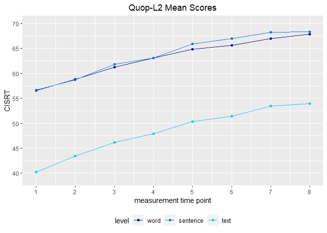

```r
#plots
#plot for all three scales
tmp <- melt(quop_sds)
names(tmp) <- c("level", "sd")
quop_plot <- melt(quop_means)
names(quop_plot)[1] <- "level"
quop_plot <- cbind(quop_plot, tmp$sd)
names(quop_plot)[3] <- "sd"
#mean plot
ggplot(quop_plot, aes(x=rep(c(1:8),3),y=value, color=level, group=level)) +
  geom_point() + geom_line() +
  scale_colour_manual(values=c("#0f0fa6", "#1477e7", "#17c8f0")) +
  labs(title="Quop-L2 Mean Scores") +
  theme(plot.title=element_text(hjust=0.5)) +
  scale_x_continuous("measurement time point",breaks=c(1:8),labels=c(1:8)) +
  scale_y_continuous("CISRT", breaks=c(40,45,50,55,60,65,70), limits=c(39,70)) +
  #theme(legend.position = c(0.09, 0.83))
  theme(legend.position = "bottom")
```

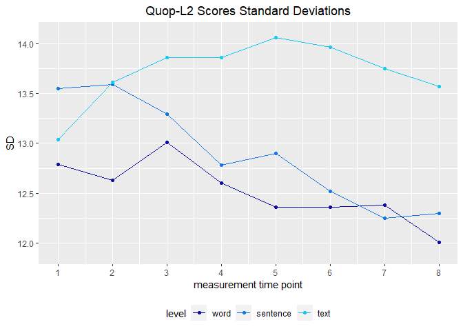

```r
ggsave("plots/quop_means.pdf", width=15,height=15,dpi=600,units="cm")
ggsave("plots/quop_means.png", width=15,height=15,dpi=600,units="cm")
#sd plot
ggplot(quop_plot, aes(x=rep(c(1:8),3),y=sd, color=level, group=level)) +
  geom_point() + geom_line() +
  scale_colour_manual(values=c("#0f0fa6", "#1477e7", "#17c8f0")) +
  labs(title="Quop-L2 Scores Standard Deviations") +
  theme(plot.title=element_text(hjust=0.5)) +
  scale_x_continuous("measurement time point",breaks=c(1:8),labels=c(1:8)) +
  scale_y_continuous("SD", breaks=c(11,11.5,12,12.5,13,13.5,14), limits=c(11.9,14.1)) +
  #theme(legend.position = c(0.09, 0.83))
  theme(legend.position = "bottom")
```

```r
ggsave("plots/quop_sds.pdf", width=15,height=15,dpi=600,units="cm")
ggsave("plots/quop_sds.png", width=15,height=15,dpi=600,units="cm")
```

- **Range of means for quop scores**
  - word: **56.59, 67.88**
  - sentence: **56.64, 68.31**
  - text: **40.29, 53.93**
- **Range of standard deviations for quop scores**
  - word: **12.01, 13.01**
  - sentence: **12.25, 13.59**
  - text: **13.04, 14.06**

### 9.1.2 Subsample

Means and standard deviations for the standardized reading tests per scale and total scores for intelligence and mathematics as well as teacher judgments per scale.

```r
#demat and cft
cft_demat_mean <- data.frame(cft=mean(elfe_quop$cft, na.rm=T), demat=mean(elfe_quop$demat_rw, na.rm=T))
cft_demat_mean <- round(cft_demat_mean, 2)
cft_demat_sd <- data.frame(cft=sd(elfe_quop$cft, na.rm=T), demat=sd(elfe_quop$demat_rw, na.rm=T))
cft_demat_sd <- round(cft_demat_sd, 2)
#cft and demat mean
(cft_demat_mean_f <- formattable(cft_demat_mean))
```

| cft | demat |
| --- | --- |
| 28.28 | 27.57 |

```r
#cft and demat sd
(cft_demat_sd_f <- formattable(cft_demat_sd))
```

| cft | demat |
| --- | --- |
| 8.38 | 6.22 |

```r
#elfe and teacher ratings
elfe_tr_mean <- data.frame(elfe_pre=c(mean(elfe_quop$w_rw_pre, na.rm=T),
                      mean(elfe_quop$s_rw_pre, na.rm=T),
                      mean(elfe_quop$t_rw_pre, na.rm=T)),
           elfe_post=c(mean(elfe_quop$w_rw_post, na.rm=T),
                       mean(elfe_quop$s_rw_post, na.rm=T),
                       mean(elfe_quop$t_rw_post, na.rm=T)),
           tr_di=c(mean(elfe_quop$tr_in_w, na.rm=T),
                   mean(elfe_quop$tr_in_s, na.rm=T),
                   mean(elfe_quop$tr_in_t, na.rm=T)),
           tr_cr=c(mean(elfe_quop$tr_di_w, na.rm=T),
                   mean(elfe_quop$tr_di_s, na.rm=T),
                   mean(elfe_quop$tr_di_t, na.rm=T)))
elfe_tr_mean <- round(elfe_tr_mean, 2)
row.names(elfe_tr_mean) <- c("w", "s", "t")
elfe_tr_sd <- data.frame(elfe_pre=c(sd(elfe_quop$w_rw_pre, na.rm=T),
                      sd(elfe_quop$s_rw_pre, na.rm=T),
                      sd(elfe_quop$t_rw_pre, na.rm=T)),
           elfe_post=c(sd(elfe_quop$w_rw_post, na.rm=T),
                       sd(elfe_quop$s_rw_post, na.rm=T),
                       sd(elfe_quop$t_rw_post, na.rm=T)),
           tr_di=c(sd(elfe_quop$tr_in_w, na.rm=T),
                   sd(elfe_quop$tr_in_s, na.rm=T),
                   sd(elfe_quop$tr_in_t, na.rm=T)),
           tr_cr=c(sd(elfe_quop$tr_di_w, na.rm=T),
                   sd(elfe_quop$tr_di_s, na.rm=T),
                   sd(elfe_quop$tr_di_t, na.rm=T)))
elfe_tr_sd <- round(elfe_tr_sd, 2)
row.names(elfe_tr_sd) <- c("w", "s", "t")
#elfe and tr mean
(elfe_tr_mean_f <- formattable(elfe_tr_mean))
```

|  | elfe_pre | elfe_post | tr_di | tr_cr |
| --- | --- | --- | --- | --- |
| w | 29.02 | 38.31 | 4.67 | 19.37 |
| s | 9.58 | 14.36 | 4.34 | 9.12 |
| t | 5.63 | 9.45 | 4.02 | 6.61 |

```r
#elfe and tr sd
(elfe_tr_sd_f <- formattable(elfe_tr_sd))
```

|  | elfe_pre | elfe_post | tr_di | tr_cr |
| --- | --- | --- | --- | --- |
| w | 9.72 | 11.16 | 1.42 | 11.40 |
| s | 5.63 | 6.41 | 1.53 | 5.20 |
| t | 4.19 | 5.24 | 1.56 | 4.44 |

- **Elfe differences (descriptive) pre post**
  - word: difference **9.29**, sd **1.44**
  - sentence: difference **4.78**, sd **0.78**
  - text: difference **3.82**, sd **1.05**

Correlations of all variables.

Function to create nice correlation tables (adapted from [here](http://www.sthda.com/english/wiki/elegant-correlation-table-using-xtable-r-package); requires Hmisc).

```r
# x is a matrix
# returns dataframe
corstars <- function(x){

  # compute correlations
  res <- rcorr(x)
  # matrix of correlation coeficients
  R <- res$r
  # matrix of p-value
  p <- res$P

  # round to two decimals
  R <- round(R, 2)
  # Make upper triangle of p-value matrix 1 so mystars will be "" there
  p[upper.tri(p, diag = TRUE)] <- 1

  #d efine notions for significance levels; spacing is important.
  mystars <- ifelse(p < .001, "***", ifelse(p < .01, "** ", ifelse(p < .05, "*  ", "   ")))

  # build a new matrix that includes the correlations with their apropriate stars
  Rnew <- matrix(paste(R, mystars, sep=""), ncol=ncol(x))
  rownames(Rnew) <- colnames(x)
  colnames(Rnew) <- paste(colnames(x), "", sep="")

  # exclude upper triangle, then make diagnonal to 1
  Rnew <- as.matrix(Rnew)
  Rnew[upper.tri(Rnew, diag = TRUE)] <- ""
  diag(Rnew) <- "1"
  # as data frame
  Rnew <- as.data.frame(Rnew)

  return(Rnew)
}
```

As we have 8 time points and 3 levels for the quop tests alone, we will exemplary only use quop scores from the second time point and show correlations with the other variables.

```r
all_cor <- corstars(as.matrix(elfe_quop[c("w_cisrt_t2", "s_cisrt_t2", "t_cisrt_t2", "w_rw_pre", "s_rw_pre", "t_rw_pre", "w_rw_post", "s_rw_post", "t_rw_post", "cft", "demat_rw", "tr_in_w", "tr_in_s", "tr_in_t", "tr_di_w", "tr_di_s", "tr_di_t")]))
names(all_cor) <- c("quop_w", "quop_s", "quop_t", "elfe_w_pre", "elfe_s_pre", "elfe_t_pre", "elfe_w_post", "elfe_s_post", "elfe_t_post", "cft", "demat", "tr_di_w", "tr_di_s", "tr_di_t", "tr_cr_w", "tr_cr_s", "tr_cr_t")
(all_cor_f <- formattable(all_cor))
```

|  | quop_w | quop_s | quop_t | elfe_w_pre | elfe_s_pre | elfe_t_pre | elfe_w_post | elfe_s_post | elfe_t_post | cft | demat | tr_di_w | tr_di_s | tr_di_t | tr_cr_w | tr_cr_s | tr_cr_t |
| --- | --- | --- | --- | --- | --- | --- | --- | --- | --- | --- | --- | --- | --- | --- | --- | --- | --- |
| w_cisrt_t2 | 1 |  |  |  |  |  |  |  |  |  |  |  |  |  |  |  |  |
| s_cisrt_t2 | 0.7*** | 1 |  |  |  |  |  |  |  |  |  |  |  |  |  |  |  |
| t_cisrt_t2 | 0.6*** | 0.65*** | 1 |  |  |  |  |  |  |  |  |  |  |  |  |  |  |
| w_rw_pre | 0.64*** | 0.68*** | 0.56*** | 1 |  |  |  |  |  |  |  |  |  |  |  |  |  |
| s_rw_pre | 0.72*** | 0.76*** | 0.7*** | 0.82*** | 1 |  |  |  |  |  |  |  |  |  |  |  |  |
| t_rw_pre | 0.54*** | 0.63*** | 0.59*** | 0.64*** | 0.78*** | 1 |  |  |  |  |  |  |  |  |  |  |  |
| w_rw_post | 0.62*** | 0.62*** | 0.47*** | 0.79*** | 0.77*** | 0.6*** | 1 |  |  |  |  |  |  |  |  |  |  |
| s_rw_post | 0.67*** | 0.69*** | 0.55*** | 0.75*** | 0.84*** | 0.68*** | 0.85*** | 1 |  |  |  |  |  |  |  |  |  |
| t_rw_post | 0.58*** | 0.64*** | 0.54*** | 0.61*** | 0.76*** | 0.74*** | 0.66*** | 0.77*** | 1 |  |  |  |  |  |  |  |  |
| cft | 0.31*** | 0.38*** | 0.34*** | 0.35*** | 0.45*** | 0.33*** | 0.38*** | 0.42*** | 0.44*** | 1 |  |  |  |  |  |  |  |
| demat_rw | 0.38*** | 0.48*** | 0.33*** | 0.48*** | 0.46*** | 0.44*** | 0.43*** | 0.43*** | 0.4*** | 0.46*** | 1 |  |  |  |  |  |  |
| tr_in_w | 0.58*** | 0.64*** | 0.51*** | 0.63*** | 0.68*** | 0.58*** | 0.66*** | 0.69*** | 0.63*** | 0.48*** | 0.54*** | 1 |  |  |  |  |  |
| tr_in_s | 0.59*** | 0.63*** | 0.51*** | 0.63*** | 0.69*** | 0.58*** | 0.67*** | 0.7*** | 0.63*** | 0.46*** | 0.54*** | 0.95*** | 1 |  |  |  |  |
| tr_in_t | 0.59*** | 0.62*** | 0.5*** | 0.65*** | 0.7*** | 0.58*** | 0.7*** | 0.72*** | 0.65*** | 0.48*** | 0.56*** | 0.91*** | 0.94*** | 1 |  |  |  |
| tr_di_w | 0.38*** | 0.39*** | 0.36*** | 0.44*** | 0.47*** | 0.39*** | 0.58*** | 0.58*** | 0.49*** | 0.35*** | 0.32*** | 0.48*** | 0.47*** | 0.46*** | 1 |  |  |
| tr_di_s | 0.48*** | 0.51*** | 0.46*** | 0.53*** | 0.61*** | 0.51*** | 0.61*** | 0.63*** | 0.54*** | 0.41*** | 0.38*** | 0.61*** | 0.63*** | 0.63*** | 0.79*** | 1 |  |
| tr_di_t | 0.45*** | 0.48*** | 0.42*** | 0.48*** | 0.57*** | 0.47*** | 0.53*** | 0.55*** | 0.48*** | 0.39*** | 0.37*** | 0.61*** | 0.63*** | 0.64*** | 0.66*** | 0.92*** | 1 |

## 9.2 Missing Data

### 9.2.1 Total Sample

Amount of quop scores missing per time point and level.

```r
#percentage quop scores
miss_quop_all <- gg_miss_var(quop_use[colnames(quop_use)[grep("(^w_|^s_|^t_)(cisrt)", colnames(quop_use))]], show_pct=TRUE)[[1]]$pct_miss
```

Corresponding plot.

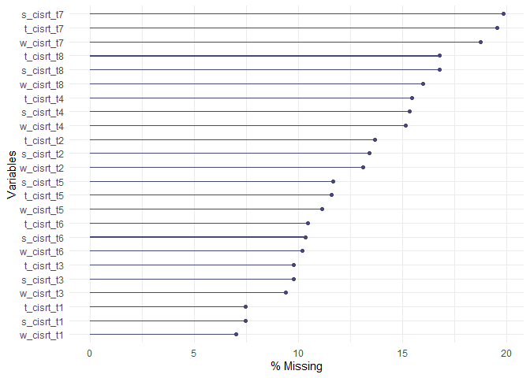

```r
gg_miss_var(quop_use[colnames(quop_use)[grep("(^w_|^s_|^t_)(cisrt)", colnames(quop_use))]], show_pct=TRUE)
```

### 9.2.2 Subsample

Amount of quop scores, standardized test scores and teacher ratings missing per time point.

```r
#percentage of quop scores
miss_quop <- gg_miss_var(elfe_quop[colnames(quop_use)[grep("(^w_|^s_|^t_)(cisrt)", colnames(quop_use))]], show_pct=TRUE)[[1]]$pct_miss
#percentage of standardized tests
miss_st <- gg_miss_var(elfe_quop[c("w_rw_pre","w_rw_post","s_rw_pre","s_rw_post","t_rw_pre","t_rw_post","demat_rw","cft")], show_pct=TRUE)[[1]]$pct_miss
#percentage of teacher ratings
miss_tr <- gg_miss_var(elfe_quop[c("tr_di_w", "tr_di_s", "tr_di_t", "tr_in_w", "tr_in_s", "tr_in_t")], show_pct=TRUE)[[1]]$pct_miss
```

Corresponding plots.

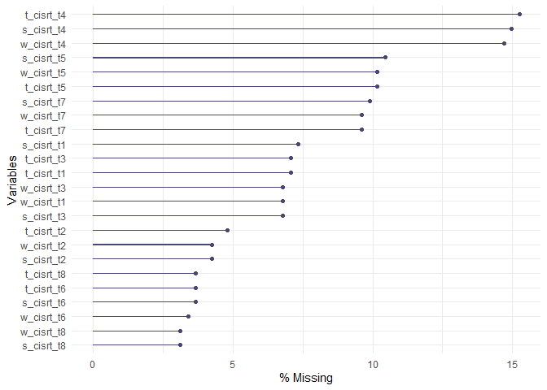

```r
#plots
#quop-data
gg_miss_var(elfe_quop[colnames(quop_use)[grep("(^w_|^s_|^t_)(cisrt)", colnames(quop_use))]], show_pct=TRUE)
```

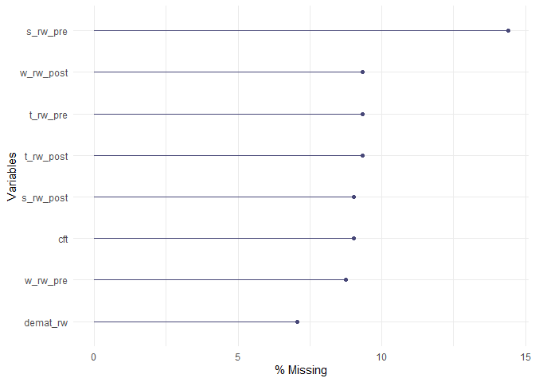

```r
#standardized tests
gg_miss_var(elfe_quop[c("w_rw_pre","w_rw_post","s_rw_pre","s_rw_post","t_rw_pre","t_rw_post","demat_rw","cft")], show_pct=TRUE)
```

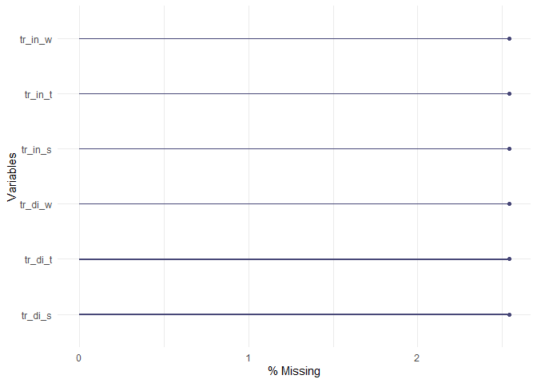

```r
#teacher ratings
gg_miss_var(elfe_quop[c("tr_di_w", "tr_di_s", "tr_di_t", "tr_in_w", "tr_in_s", "tr_in_t")], show_pct=TRUE)
```

For correlational analyses, all pairs available will be used. How many are these per quop time point and variable the quop score is going to be correlated with?

```r
#complete cases for correlations
complete_cases <- function(df=elfe_quop, var1, var2){
  miss_case <- gg_miss_case(df[c(var1, var2)], show_pct=TRUE)[[1]]
  #return pairwise complete cases
  return(length(miss_case$case[miss_case$n_miss==0]))
}

#ELFE
elfe_w_pre <- mapply(function(var1, var2)complete_cases(var1=var1, var2=var2), var1=paste0("w_cisrt_t",rep(1:8)), var2=rep("w_rw_pre",each=8))

elfe_s_pre <- mapply(function(var1, var2)complete_cases(var1=var1, var2=var2), var1=paste0("s_cisrt_t",rep(1:8)), var2=rep("s_rw_pre",each=8))

elfe_t_pre <- mapply(function(var1, var2)complete_cases(var1=var1, var2=var2), var1=paste0("t_cisrt_t",rep(1:8)), var2=rep("t_rw_pre",each=8))

elfe_w_post <- mapply(function(var1, var2)complete_cases(var1=var1, var2=var2), var1=paste0("w_cisrt_t",rep(1:8)), var2=rep("w_rw_post",each=8))

elfe_s_post <- mapply(function(var1, var2)complete_cases(var1=var1, var2=var2), var1=paste0("s_cisrt_t",rep(1:8)), var2=rep("s_rw_post",each=8))

elfe_t_post <- mapply(function(var1, var2)complete_cases(var1=var1, var2=var2), var1=paste0("t_cisrt_t",rep(1:8)), var2=rep("t_rw_post",each=8))

#TEACHER RATINGS
tr_di_w <- mapply(function(var1, var2)complete_cases(var1=var1, var2=var2), var1=paste0("w_cisrt_t",rep(1:8)), var2=rep("tr_in_w",each=8))

tr_di_s <- mapply(function(var1, var2)complete_cases(var1=var1, var2=var2), var1=paste0("s_cisrt_t",rep(1:8)), var2=rep("tr_in_s",each=8))

tr_di_t <- mapply(function(var1, var2)complete_cases(var1=var1, var2=var2), var1=paste0("t_cisrt_t",rep(1:8)), var2=rep("tr_in_t",each=8))

tr_cr_w <- mapply(function(var1, var2)complete_cases(var1=var1, var2=var2), var1=paste0("w_cisrt_t",rep(1:8)), var2=rep("tr_di_w",each=8))

tr_cr_s <- mapply(function(var1, var2)complete_cases(var1=var1, var2=var2), var1=paste0("s_cisrt_t",rep(1:8)), var2=rep("tr_di_s",each=8))

tr_cr_t <- mapply(function(var1, var2)complete_cases(var1=var1, var2=var2), var1=paste0("t_cisrt_t",rep(1:8)), var2=rep("tr_di_t",each=8))

#CFT AND DEMAT
discr_pairs <- function(df=elfe_quop, score1=quop_score, score2="cft"){
  #standardize
  df_scaled <- scale(df[,score1])
  total_scores <- apply(df_scaled[,score1], 1, mean)
  #check fully complete pairs
  df_miss <- data.frame(total_scores=total_scores, score2=df[,score2])
  miss <- gg_miss_case(df_miss, show_pct=TRUE)[[1]]
  full_pairs <- length(miss$case[miss$n_miss==0])
  return(full_pairs)
}

#variable names for total quop scores per time point
quop_scores <- list()
for(i in time_pts){
  quop_scores[[i]] <- c(paste0("w_cisrt_t",i), paste0("s_cisrt_t",i),paste0("t_cisrt_t",i))
}

cft <- mapply(function(score1, score2)discr_pairs(score1=score1, score2=score2), score1=quop_scores, score2=rep("cft",each=8))

demat <- mapply(function(score1, score2)discr_pairs(score1=score1, score2=score2), score1=quop_scores, score2=rep("demat_rw",each=8))

#DATAFRAME WITH RESULTS
full_pairs <- data.frame(elfe_w_pre=elfe_w_pre,elfe_s_pre=elfe_s_pre,elfe_t_pre=elfe_t_pre,elfe_w_post=elfe_w_post,elfe_s_post=elfe_s_post,elfe_t_post=elfe_t_post,tr_di_w=tr_di_w,tr_di_s=tr_di_s,tr_di_t=tr_di_t,tr_cr_w=tr_cr_w,tr_cr_s=tr_cr_s,tr_cr_t=tr_cr_t,cft=cft,demat=demat)
row.names(full_pairs) <- c(paste0("t",seq(1,8)))

#formattable
(full_pairs_f <- formattable(full_pairs))
```

|  | elfe_w_pre | elfe_s_pre | elfe_t_pre | elfe_w_post | elfe_s_post | elfe_t_post | tr_di_w | tr_di_s | tr_di_t | tr_cr_w | tr_cr_s | tr_cr_t | cft | demat |
| --- | --- | --- | --- | --- | --- | --- | --- | --- | --- | --- | --- | --- | --- | --- |
| t1 | 305 | 284 | 303 | 298 | 298 | 297 | 328 | 326 | 327 | 328 | 326 | 327 | 302 | 309 |
| t2 | 311 | 292 | 310 | 308 | 309 | 306 | 334 | 334 | 332 | 334 | 334 | 332 | 310 | 315 |
| t3 | 302 | 285 | 301 | 302 | 302 | 300 | 324 | 324 | 323 | 324 | 324 | 323 | 302 | 306 |
| t4 | 273 | 256 | 269 | 290 | 292 | 289 | 295 | 294 | 293 | 295 | 294 | 293 | 271 | 278 |
| t5 | 289 | 274 | 288 | 305 | 304 | 304 | 309 | 308 | 309 | 309 | 308 | 309 | 287 | 292 |
| t6 | 312 | 294 | 309 | 312 | 313 | 313 | 334 | 333 | 333 | 334 | 333 | 333 | 310 | 315 |
| t7 | 289 | 274 | 287 | 293 | 293 | 293 | 311 | 310 | 311 | 311 | 310 | 311 | 291 | 296 |
| t8 | 312 | 294 | 308 | 314 | 315 | 313 | 334 | 334 | 332 | 334 | 334 | 332 | 311 | 316 |

- Complete value pairs for correlational analyses
- Median: **309**
- Range: **256, 334**

## 9.3 Reliability

**Split-Half Reliability** (odd-even) of all tests per scale.

```r
split_half_rel <- data.frame(test=c(1:8))
split_half_rel_p <- data.frame(test=c(1:8))

scales <- c("w","s","t")
time_pts <- c(1:8)
items_start <- c(1, 21, 34)
items_end <- c(20, 33, 46)
for(h in 1:length(scales)){

  cors <- 0
  ps <- 0

  for (i in time_pts){

    eval(parse(text=paste0("cors <- append(cors, rcorr(apply(quop_use[paste0(\"t",i,"_cisrt\",seq(",items_start[h],",",items_end[h],",by=2))],1,sum,na.rm=T), apply(quop_use[paste0(\"t",i,"_cisrt\",seq(",items_start[h]+1,",",items_end[h],",by=2))],1,sum,na.rm=T))[[1]][1,2])")))
    eval(parse(text=paste0("ps <- append(ps, rcorr(apply(quop_use[paste0(\"t",i,"_cisrt\",seq(",items_start[h],",",items_end[h],",by=2))],1,sum,na.rm=T), apply(quop_use[paste0(\"t",i,"_cisrt\",seq(",items_start[h]+1,",",items_end[h],",by=2))],1,sum,na.rm=T))[[3]][1,2])")))
  }
  cors <- cors[-1]
  ps <- ps[-1]
  eval(parse(text=paste0("split_half_rel$",scales[h]," <- cors")))
  eval(parse(text=paste0("split_half_rel_p$",scales[h]," <- ps")))
}

#format as table
split_half_rel <- round(split_half_rel[-1],2)
row.names(split_half_rel) <- c(paste0("t",seq(1,8)))
(split_half_rel_f <- formattable(split_half_rel))
```

|  | w | s | t |
| --- | --- | --- | --- |
| t1 | 0.82 | 0.86 | 0.65 |
| t2 | 0.86 | 0.89 | 0.74 |
| t3 | 0.85 | 0.87 | 0.74 |
| t4 | 0.88 | 0.90 | 0.77 |
| t5 | 0.86 | 0.90 | 0.77 |
| t6 | 0.84 | 0.89 | 0.75 |
| t7 | 0.89 | 0.92 | 0.83 |
| t8 | 0.88 | 0.91 | 0.81 |

- **Median split-half reliabilities**
  - Word: **0.86**
  - Sentence: **0.895**
  - Text: **0.76**
- **Range of split-half reliabilites**
  - Word: **0.82, 0.89**
  - Sentence: **0.86, 0.92**
  - Text: **0.65, 0.83**
- **Maximal p-values**
  - Word: **0**
  - Sentence: **0**
  - Text: **0**

**Retest-Reliability** of sucessive tests per scale.

```r
retest_idx <- function(test_points){
  #minus one time due to 1-based indexing
  idx <- 2+test_points*(length(time_pts)+1) - 1*(length(time_pts)+1)
  return(idx)
}

##word
#coefficients
retest_w <- rcorr(as.matrix(quop_use[,which(colnames(quop_use)=="w_cisrt_t1"):which(colnames(quop_use)=="w_cisrt_t8")]))[[1]]
retest_rel_w <- retest_w[retest_idx(1:7)]
#p-values
retest_w_p <- rcorr(as.matrix(quop_use[,which(colnames(quop_use)=="w_cisrt_t1"):which(colnames(quop_use)=="w_cisrt_t8")]))[[3]]
retest_rel_w_p <- retest_w_p[retest_idx(1:7)]

#sentence
retest_s <- rcorr(as.matrix(quop_use[,which(colnames(quop_use)=="s_cisrt_t1"):which(colnames(quop_use)=="s_cisrt_t8")]))[[1]]
retest_rel_s <- retest_s[retest_idx(1:7)]
retest_s_p <- rcorr(as.matrix(quop_use[,which(colnames(quop_use)=="s_cisrt_t1"):which(colnames(quop_use)=="s_cisrt_t8")]))[[3]]
retest_rel_s_p <- retest_s_p[retest_idx(1:7)]

#text
retest_t <- rcorr(as.matrix(quop_use[,which(colnames(quop_use)=="s_cisrt_t1"):which(colnames(quop_use)=="s_cisrt_t8")]))[[1]]
retest_rel_t <- retest_t[retest_idx(1:7)]
retest_t_p <- rcorr(as.matrix(quop_use[,which(colnames(quop_use)=="s_cisrt_t1"):which(colnames(quop_use)=="s_cisrt_t8")]))[[3]]
retest_rel_t_p <- retest_t_p[retest_idx(1:7)]

#into one df
retest_rel <- as.data.frame(t(data.frame(word=retest_rel_w, sentence=retest_rel_s, text=retest_rel_t)))
names(retest_rel) <- c(paste0("t",seq(1,7),"_t",seq(2,8)))

#format as table
retest_rel <- round(retest_rel,2)
#transpose
retest_rel <- as.data.frame(as.matrix(t(retest_rel)))
(retest_rel_f <- formattable(retest_rel))
```

|  | word | sentence | text |
| --- | --- | --- | --- |
| t1_t2 | 0.69 | 0.68 | 0.68 |
| t2_t3 | 0.69 | 0.66 | 0.66 |
| t3_t4 | 0.71 | 0.67 | 0.67 |
| t4_t5 | 0.66 | 0.65 | 0.65 |
| t5_t6 | 0.63 | 0.64 | 0.64 |
| t6_t7 | 0.65 | 0.66 | 0.66 |
| t7_t8 | 0.63 | 0.65 | 0.65 |

- **Median retest reliabilities**
  - Word: **0.66**
  - Sentence: **0.66**
  - Text: **0.66**
- **Range of retest reliabilites**
  - Word: **0.63, 0.71**
  - Sentence: **0.64, 0.68**
  - Text: **0.64, 0.68**
- **Maximal p-values**
  - Word: **0**
  - Sentence: **0**
  - Text: **0**

# 10 Validity Analyses

We have three research questions:

1. Structural validity: Does the test reflect the proposed three-dimensional structure of reading comprehension conceptualized as efficient component processes on word, sentence, and text level?
2. Status validity: Does a single test score at a single point in time validly measure the current level of reading comprehension?
3. Slope validity: Does change in test scores over time validly measure progress in reading comprehension?
- This includes validly measuring progress and using this progress to
- successfully predict end-of-term performance

## 10.1 Structural Validity

Confirmatory Factory Analyses (CFAs) for each testing point to verify the assumed model structure. We assume that the item scores for each scale capture an individual latent variable (although the three latent variables representing word, sentence and text scale are intercorrelated). The CFAs are estimated with three item parcels per scale. The parcels are built by counterbalancing item positions. This means that for each scale, the first item goes into the first parcel, the second item goes into the second parcel, the third item into the third parcel, the fourth item again into the first parcel and so on:

Build parcels by dividing each scale into three groups.

- Group 1: 1., 4., 7., … item
- Group 2: 2., 5., 8., … item
- Group 3: 3., 6., 9., … item

The model looks like this:

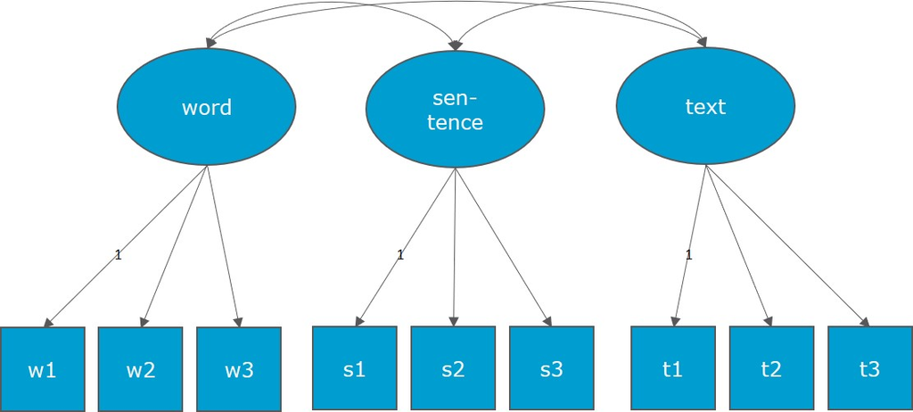

Structural Validity Model

```r
quop_parcels <- quop_use[,c("code","class")]
#For each scale, for each testing ponit

#CREATING DF QUOP_PARCELS
#WITHOUT SCALE()
for(h in 1:length(scales)){

  for(i in time_pts){
    #first parcel
    eval(parse(text=paste0("quop_parcels$",scales[h],"_t",i,"_parcel1 <- ifelse(
                           apply(quop_use[,paste0(\"t",i,"_cisrt\",",items_start[h],":",items_end[h],")],1,function(x){all(is.na(x))}),
                           NA,
                           rowMeans(quop_use[,paste0(\"t",i,"_cisrt\",seq(",items_start[h],",",items_end[h],",by=3))],na.rm=T))")))
    #second parcel
    eval(parse(text=paste0("quop_parcels$",scales[h],"_t",i,"_parcel2 <- ifelse(
                           apply(quop_use[,paste0(\"t",i,"_cisrt\",",items_start[h],":",items_end[h],")],1,function(x){all(is.na(x))}),
                           NA,
                           rowMeans(quop_use[,paste0(\"t",i,"_cisrt\",seq(",items_start[h]+1,",",items_end[h],",by=3))],na.rm=T))")))
    #third parcel
    eval(parse(text=paste0("quop_parcels$",scales[h],"_t",i,"_parcel3 <- ifelse(
                           apply(quop_use[,paste0(\"t",i,"_cisrt\",",items_start[h],":",items_end[h],")],1,function(x){all(is.na(x))}),
                           NA,
                           rowMeans(quop_use[,paste0(\"t",i,"_cisrt\",seq(",items_start[h]+2,",",items_end[h],",by=3))],na.rm=T))")))
  }
}

#Make NaNs to NA
#is.nan() behaves differently than is.na() for dataframes but for a matrix, it works just like is.na() does for dataframes
quop_parcels[is.nan(as.matrix(quop_parcels))] <- NA
```

The parcels are merged into our two dataframes (quop scores for the whole sample and quop scores as well as standardized test scores and teacher judgments for the subsample).

```r
#Add quop parcels to quop_use and to elfe_quop
quop_use <- merge(quop_use, quop_parcels, by=c("code","class"))
elfe_quop <- merge(elfe_quop, quop_parcels, by=c("code","class"))
```

And CFAs are estimated, reporting the two most common abosulte and incremental fit indices, respectively.

```r
#CFA for eacht testing point
#empty df (df has typed columns, so each column's type needs to be declared)
fit_msrs <- data.frame(RMSEA=double(),SRMR=double(),CFI=double(),TLI=double())
#rbind messes with column names so save them and reassign them later
names_fit_msrs <- names(fit_msrs)

tests <- c(1:8)
for(i in tests){
  eval(parse(text=paste0("quop_model <- \"w =~ w_t",i,"_parcel1 + w_t",i,"_parcel2 + w_t",i,"_parcel3
                         s =~ s_t",i,"_parcel1 + s_t",i,"_parcel2 + s_t",i,"_parcel3
                         t =~ t_t",i,"_parcel1 + t_t",i,"_parcel2 + t_t",i,"_parcel3\"")))
  fit <- cfa(quop_model, data=quop_use, missing="fiml", cluster="class")
  #summary(fit, fit.measures=T, standardized=T)

  #Store fit indices
  fit_msrs <- rbind(fit_msrs, as.vector(fitMeasures(fit)[c("rmsea", "srmr","cfi", "tli")]))
  #make sure the colnames are correct
  names(fit_msrs) <- names_fit_msrs
}

#add row names to identify testing points
row.names(fit_msrs) <- c(paste0("t",rep(1:8)))
#all fit msrs
(fit_msrs_f <- formattable(round(fit_msrs,3)))
```

|  | RMSEA | SRMR | CFI | TLI |
| --- | --- | --- | --- | --- |
| t1 | 0.038 | 0.021 | 0.986 | 0.979 |
| t2 | 0.038 | 0.020 | 0.987 | 0.981 |
| t3 | 0.034 | 0.020 | 0.991 | 0.986 |
| t4 | 0.029 | 0.017 | 0.992 | 0.988 |
| t5 | 0.032 | 0.019 | 0.990 | 0.985 |
| t6 | 0.032 | 0.018 | 0.991 | 0.986 |
| t7 | 0.040 | 0.020 | 0.985 | 0.977 |
| t8 | 0.025 | 0.016 | 0.993 | 0.990 |

```r
#range (worst and best)
#best values for absolute fit indices (the smaller the better) and incremental fit indices (the bigger the better)
best <- c(apply(fit_msrs[,c(1,2)],2,min), apply(fit_msrs[,c(3,4)],2,max))
#worst values
worst <- c(apply(fit_msrs[,c(1,2)],2,max), apply(fit_msrs[,c(3,4)],2,min))
#put them together
range_fit_indices <- rbind(worst,best)
#round
range_fit_indices <- round(range_fit_indices,3)
#nice table
(range_fit_indices_f <- formattable(as.data.frame(range_fit_indices)))
```

|  | RMSEA | SRMR | CFI | TLI |
| --- | --- | --- | --- | --- |
| worst | 0.040 | 0.021 | 0.985 | 0.977 |
| best | 0.025 | 0.016 | 0.993 | 0.990 |

## 10.2 Status Validity

### 10.2.1 Discriminant Status Validity

Indicator: Correlation of overall quop scores of all time points with cft (intelligence) and demat (mathematics) standardized test scores.

```r
#calcualte total score and correlation with discriminant measure for one timepoint
discr_validity <- function(df=elfe_quop, score1=quop_score, score2="cft"){
  #standardize
  df_scaled <- scale(df[,score1])
  total_scores <- apply(df_scaled[,score1], 1, mean)
  #cor_div <- cor(total_scores, df[,score2], use="complete.obs")
  #correlation
  cor_div <- rcorr(total_scores, df[,score2])[[1]][1,2]
  #p-value
  cor_div_p <- rcorr(total_scores, df[,score2])[[3]][1,2]
  return(c(cor_div, cor_div_p))
}

#variable names for total quop scores per time point
quop_scores <- list()
for(i in time_pts){
  quop_scores[[i]] <- c(paste0("w_cisrt_t",i), paste0("s_cisrt_t",i),paste0("t_cisrt_t",i))
}

#over all timepoints (first 8 results are cft, second 8 are demat)
discr_cors <- mapply(function(score1, score2)discr_validity(score1=score1, score2=score2), score1=quop_scores, score2=rep(c("cft", "demat_rw"),each=8), SIMPLIFY=FALSE)
discr_cors <- t(simplify2array(discr_cors))

#into df
discriminant <- data.frame(Intelligence=round(discr_cors[1:8,1],2), Mathematics=round(discr_cors[9:16,1],2))
row.names(discriminant) <- c(paste0("t",seq(1,8)))

#format as table
(discriminant_f <- formattable(discriminant))
```

|  | Intelligence | Mathematics |
| --- | --- | --- |
| t1 | 0.43 | 0.40 |
| t2 | 0.39 | 0.45 |
| t3 | 0.38 | 0.44 |
| t4 | 0.32 | 0.40 |
| t5 | 0.40 | 0.43 |
| t6 | 0.40 | 0.47 |
| t7 | 0.37 | 0.43 |
| t8 | 0.36 | 0.42 |

- **CFT (Intelligence)**
  - Median correlation: **0.385**
  - Range of correlations: **0.32, 0.43**
  - Maximal p-value: **0**
- **DEMAT (Mathematics)**
  - Median correlation: **0.43**
  - Range of correlations: **0.4, 0.47**
  - Maximal p-value: **0**

#### 10.2.1.1 Disattenuated Discriminant Status Validity

As reliability is not perfect, estimate divergent correlations as they would be when having perfect reliability.

```r
#split-half reliability of total quop scores
sh_total <- function(data, score, n_items){
  quop_items <- data[,grep(score, colnames(data))]
  sh_total <- cor(apply(quop_items[,seq(1,n_items,by=2)],1,sum,na.rm=T), apply(quop_items[,seq(2,n_items,by=2)],1,sum,na.rm=T), use="pairwise.complete.obs")
  return(sh_total)
}

#apply over all time points
sh_quop <- mapply(function(score){sh_total(quop_use, score, n_items)}, score=c(paste0("t",rep(1:8),"_cisrt")))

#reliabilities of demat and cft
rel_cft <- .94 #retest-reliability according to manual
rel_demat <- .88 #internal sonsistencies second grade according to manual

#compute disattenuations
disatt_cft <- discriminant$Intelligence / (sqrt(sh_quop) * sqrt(rel_cft))
disatt_demat <- discriminant$Mathematics / (sqrt(sh_quop) * sqrt(rel_demat))

#into df
discriminant_dis <- data.frame(Intelligence=disatt_cft, Mathematics=disatt_demat)
discriminant_dis <- round(discriminant_dis, 2)
row.names(discriminant_dis) <- c(paste0("t",seq(1,8)))

#format as table
(discriminant_dis_f <- formattable(discriminant_dis))
```

|  | Intelligence | Mathematics |
| --- | --- | --- |
| t1 | 0.46 | 0.45 |
| t2 | 0.42 | 0.50 |
| t3 | 0.41 | 0.49 |
| t4 | 0.34 | 0.44 |
| t5 | 0.43 | 0.47 |
| t6 | 0.43 | 0.52 |
| t7 | 0.39 | 0.47 |
| t8 | 0.38 | 0.46 |

### 10.2.2 Convergent Status Validity

#### 10.2.2.1 Correlations with ELFE

Indicator: Correlation of quop scores per scale with elfe (reading) scores per scale (across all timepoints; 1-8 for quop, pre and post for elfe).

```r
#calcualte total score and correlation with convergent measure for one timepoint
conv_validity <- function(df=elfe_quop, score1=rep(paste0("w_cisrt_t",seq(1,8)),2), score2=rep(c("w_rw_pre", "w_rw_post"),each=8)){
  mapply(function(score1, score2){
    #correlation
    conv_cor <- rcorr(elfe_quop[,score1], elfe_quop[,score2])[[1]][1,2]
    #p-value
    conv_cor_p <- rcorr(elfe_quop[,score1], elfe_quop[,score2])[[3]][1,2]
    return(c(conv_cor, conv_cor_p))
    }, score1, score2, SIMPLIFY=FALSE)
}

#word level
#first eight are pre, second eight are post
conv_cors_w <- t(simplify2array(conv_validity()))

#sentence level
conv_cors_s <- t(simplify2array(conv_validity(score1=rep(paste0("s_cisrt_t",seq(1,8)),2), score2=rep(c("s_rw_pre", "s_rw_post"),each=8))))

#text level
conv_cors_t <- t(simplify2array(conv_validity(score1=rep(paste0("t_cisrt_t",seq(1,8)),2), score2=rep(c("t_rw_pre", "t_rw_post"),each=8))))

#into dfs
#word
convergent_w <- data.frame(ELFE_pre=round(conv_cors_w[1:8,1],2), ELFE_post=round(conv_cors_w[9:16,1],2))
row.names(convergent_w) <- c(paste0("t",seq(1,8)))

#sentence
convergent_s <- data.frame(ELFE_pre=round(conv_cors_s[1:8,1],2), ELFE_post=round(conv_cors_s[9:16,1],2))
row.names(convergent_s) <- c(paste0("t",seq(1,8)))

#text
convergent_t <- data.frame(ELFE_pre=round(conv_cors_t[1:8,1],2), ELFE_post=round(conv_cors_t[9:16,1],2))
row.names(convergent_t) <- c(paste0("t",seq(1,8)))

#format as tables
#word
(convergent_w_f <- formattable(convergent_w))
```

|  | ELFE_pre | ELFE_post |
| --- | --- | --- |
| t1 | 0.65 | 0.65 |
| t2 | 0.64 | 0.62 |
| t3 | 0.65 | 0.66 |
| t4 | 0.62 | 0.62 |
| t5 | 0.62 | 0.64 |
| t6 | 0.60 | 0.65 |
| t7 | 0.64 | 0.64 |
| t8 | 0.60 | 0.62 |

```r
#sentence
(convergent_s_f <- formattable(convergent_s))
```

|  | ELFE_pre | ELFE_post |
| --- | --- | --- |
| t1 | 0.81 | 0.71 |
| t2 | 0.76 | 0.69 |
| t3 | 0.77 | 0.73 |
| t4 | 0.76 | 0.76 |
| t5 | 0.74 | 0.75 |
| t6 | 0.68 | 0.73 |
| t7 | 0.72 | 0.74 |
| t8 | 0.65 | 0.71 |

```r
#text
(convergent_t_f <- formattable(convergent_t))
```

|  | ELFE_pre | ELFE_post |
| --- | --- | --- |
| t1 | 0.52 | 0.53 |
| t2 | 0.59 | 0.54 |
| t3 | 0.54 | 0.57 |
| t4 | 0.63 | 0.61 |
| t5 | 0.56 | 0.62 |
| t6 | 0.61 | 0.64 |
| t7 | 0.61 | 0.65 |
| t8 | 0.61 | 0.66 |

- **Word level**
  - ELFE_pre
    - Median correlation: **0.63**
    - Range of correlations: **0.6, 0.65**
    - Maximal p-value: **0**
  - ELFE_post
    - Median correlation: **0.64**
    - Range of correlations: **0.62, 0.66**
    - Maximal p-value: **0**
- **Sentence level**
  - ELFE_pre
    - Median correlation: **0.75**
    - Range of correlations: **0.65, 0.81**
    - Maximal p-value: **0**
  - ELFE_post
    - Median correlation: **0.73**
    - Range of correlations: **0.69, 0.76**
    - Maximal p-value: **0**
- **Text level**
  - ELFE_pre
    - Median correlation: **0.6**
    - Range of correlations: **0.52, 0.63**
    - Maximal p-value: **0**
  - ELFE_post
    - Median correlation: **0.62**
    - Range of correlations: **0.53, 0.66**
    - Maximal p-value: **0**

##### 10.2.2.1.1 Disattenuated Correlations with ELFE

As reliability is not perfect, estimate convergent correlations as they would be when having perfect reliability.

```r
#from elfe manual: split-half reliailities for pencil-paper-version in grade 2 (p. 38)
sh_w_elfe <- .98
sh_s_elfe <- .95
sh_t_elfe <- .87

#compute disattenuations
disatt_w <- convergent_w / (sqrt(split_half_rel$w) * sqrt(sh_w_elfe))
disatt_s <- convergent_s / (sqrt(split_half_rel$s) * sqrt(sh_s_elfe))
disatt_t <- convergent_t / (sqrt(split_half_rel$t) * sqrt(sh_t_elfe))

#round
disatt_w <- round(disatt_w, 2)
disatt_s <- round(disatt_s, 2)
disatt_t <- round(disatt_t, 2)

#format as table
#word
(disatt_w_f <- formattable(disatt_w))
```

|  | ELFE_pre | ELFE_post |
| --- | --- | --- |
| t1 | 0.73 | 0.73 |
| t2 | 0.70 | 0.68 |
| t3 | 0.71 | 0.72 |
| t4 | 0.67 | 0.67 |
| t5 | 0.68 | 0.70 |
| t6 | 0.66 | 0.72 |
| t7 | 0.69 | 0.69 |
| t8 | 0.65 | 0.67 |

```r
#sentence
(disatt_s_f <- formattable(disatt_s))
```

|  | ELFE_pre | ELFE_post |
| --- | --- | --- |
| t1 | 0.90 | 0.79 |
| t2 | 0.83 | 0.75 |
| t3 | 0.85 | 0.80 |
| t4 | 0.82 | 0.82 |
| t5 | 0.80 | 0.81 |
| t6 | 0.74 | 0.79 |
| t7 | 0.77 | 0.79 |
| t8 | 0.70 | 0.76 |

```r
#text
(disatt_t_f <- formattable(disatt_t))
```

|  | ELFE_pre | ELFE_post |
| --- | --- | --- |
| t1 | 0.69 | 0.70 |
| t2 | 0.74 | 0.67 |
| t3 | 0.67 | 0.71 |
| t4 | 0.77 | 0.75 |
| t5 | 0.68 | 0.76 |
| t6 | 0.76 | 0.79 |
| t7 | 0.72 | 0.76 |
| t8 | 0.73 | 0.79 |

#### 10.2.2.2 Teacher Ratings

Indicator: Correlation of quop scores per scale with teacher judgments per scale.

We have a dimensional rating (1-7) and a criterial judgment (how many words can a suject read in 2 min) from a teacher for each subject. The correlation between quop scores for each scale and the ratings/judgments is used as an indicator for convergent validity.

As one teacher evaluates all students of his class, we have nested data. So, we calculate the correlation per class, fisher-z-standardize it, get the mean correlation and transform it back. P-values are calculated based on the mean fisher-z-correlations.

```r
criterial_validity <- function(df=elfe_quop, group="class", score1="w_cisrt_t1", score2="tr_in_w"){
  #x are the dataframe subsets generated by ddply
  #if inside a class, all quop scores are missing, the correlation in this class is set to NA
  cors <- ddply(df, group, function(x)if(sum(is.na(x[, score1])) == length(x[, score1])){
    data.frame(cor=NA)}
    else{
      data.frame(cor=rcorr(x[, score1], x[, score2])[[1]][1,2])
      })
    #mean correlation
    mean_cor <- mean(fisherz(cors$cor), na.rm=T)
    #number of observations going into the mean correlation
    n <- rcorr(df[, score1], df[, score2])[[2]][1,2]
    #p-value (two-sided)
    SE <- sqrt(1/(n-3))
    Z <- mean_cor / SE
    p <- 2*pnorm(-abs(Z))

  return(c(fisherz2r(mean_cor), p))
}

#word scale
#first 8 results are the time points correlations with tr_in_w, second 8 results the correlations with tr_di_w
criter_cors_w <- t(mapply(function(score1, score2)criterial_validity(elfe_quop, "class", score1=score1, score2=score2), rep(paste0("w_cisrt_t",seq(1,8)),2), rep(c("tr_in_w", "tr_di_w"),each=8)))

#sentence scale
criter_cors_s <- t(mapply(function(score1, score2)criterial_validity(elfe_quop, "class", score1=score1, score2=score2), rep(paste0("s_cisrt_t",seq(1,8)),2), rep(c("tr_in_s", "tr_di_s"),each=8)))

#text scale
criter_cors_t <- t(mapply(function(score1, score2)criterial_validity(elfe_quop, "class", score1=score1, score2=score2), rep(paste0("t_cisrt_t",seq(1,8)),2), rep(c("tr_in_t", "tr_di_t"),each=8)))

#into dfs
#word
criterial_w <- data.frame(Teacher_Rating_Dimensional=round(criter_cors_w[1:8,1],2), Teacher_Rating_Criterial=round(criter_cors_w[9:16,1],2))
row.names(criterial_w) <- c(paste0("t",seq(1,8)))

#sentence
criterial_s <- data.frame(Teacher_Rating_Dimensional=round(criter_cors_s[1:8,1],2), Teacher_Rating_Criterial=round(criter_cors_s[9:16,1],2))
row.names(criterial_s) <- c(paste0("t",seq(1,8)))

#text
criterial_t <- data.frame(Teacher_Rating_Dimensional=round(criter_cors_t[1:8,1],2), Teacher_Rating_Criterial=round(criter_cors_t[9:16,1],2))
row.names(criterial_t) <- c(paste0("t",seq(1,8)))

#format as tables
#word
(criterial_w_f <- formattable(criterial_w))
```

|  | Teacher_Rating_Dimensional | Teacher_Rating_Criterial |
| --- | --- | --- |
| t1 | 0.68 | 0.68 |
| t2 | 0.63 | 0.59 |
| t3 | 0.67 | 0.63 |
| t4 | 0.57 | 0.56 |
| t5 | 0.63 | 0.64 |
| t6 | 0.64 | 0.62 |
| t7 | 0.61 | 0.55 |
| t8 | 0.63 | 0.58 |

```r
#sentence
(criterial_s_f <- formattable(criterial_s))
```

|  | Teacher_Rating_Dimensional | Teacher_Rating_Criterial |
| --- | --- | --- |
| t1 | 0.65 | 0.65 |
| t2 | 0.67 | 0.66 |
| t3 | 0.65 | 0.63 |
| t4 | 0.65 | 0.62 |
| t5 | 0.67 | 0.68 |
| t6 | 0.66 | 0.66 |
| t7 | 0.61 | 0.62 |
| t8 | 0.62 | 0.64 |

```r
#text
(criterial_t_f <- formattable(criterial_t))
```

|  | Teacher_Rating_Dimensional | Teacher_Rating_Criterial |
| --- | --- | --- |
| t1 | 0.42 | 0.41 |
| t2 | 0.54 | 0.53 |
| t3 | 0.55 | 0.50 |
| t4 | 0.58 | 0.56 |
| t5 | 0.60 | 0.58 |
| t6 | 0.65 | 0.62 |
| t7 | 0.64 | 0.60 |
| t8 | 0.62 | 0.61 |

- **Word level**
  - Teacher Ratings Dimensional
    - Median Correlation: **0.63**
    - Range of correlations: **0.57, 0.68**
    - Maximal p-value: **0**
  - Teacher Ratings Criterial
    - Median Correlation: **0.6**
    - Range of correlations: **0.55, 0.68**
    - Maximal p-value: **0**
- **Sentence level**
  - Teacher Ratings Dimensional
    - Median Correlation: **0.65**
    - Range of correlations: **0.61, 0.67**
    - Maximal p-value: **0**
  - Teacher Ratings Criterial
    - Median Correlation: **0.64**
    - Range of correlations: **0.62, 0.68**
    - Maximal p-value: **0**
- **Text level**
  - Teacher Ratings Dimensional
    - Median Correlation: **0.59**
    - Range of correlations: **0.42, 0.65**
    - Maximal p-value: **0**
  - Teacher Ratings Criterial
    - Median Correlation: **0.57**
    - Range of correlations: **0.41, 0.62**
    - Maximal p-value: **0**

## 10.3 Validity of Change Measurement

### 10.3.1 Quop-L2 Slope and ELFE pre-post Difference

First indicator: Correlation of the slope of a linear latent growth model estimated over all quop scores (testing points 1 to 8) with the latent difference between elfe pre and post scores of a Latent Change Model.

The model looks like this:

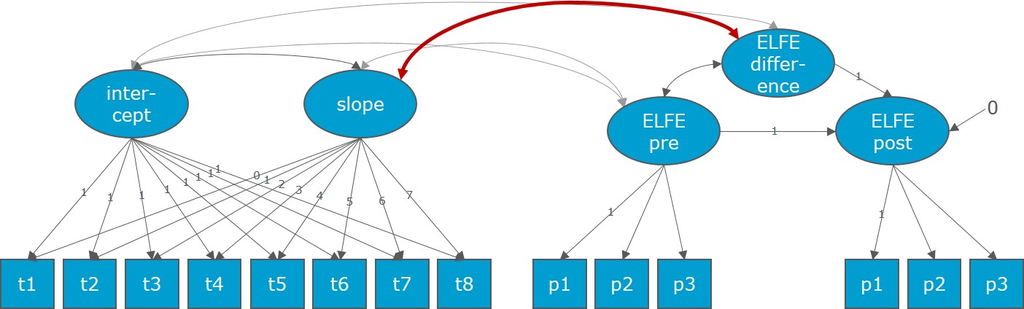

Validity of Change Measurement Model 1

First, we build 3 elfe parcels per scale according to the quop parcels.

```r
elfe_parcels <- quop_use[,c("code","class")]
tests <- c("", "_2")
scales <- c("Wort", "Satz", "Text")
new_scales <- c("w", "s", "t")
items_start <- c(1, 1, 1)
items_end <- c(75, 36, 26)
#For each scale, for each testing point

#WITHOUT SCALE()
for(h in 1:length(scales)){

  for(i in tests){
    #first parcel
    eval(parse(text=paste0("elfe_parcels$",new_scales[h],"_elfe",which(tests==i),"_parcel1 <- ifelse(
                           apply(quop_use[,paste0(\"",scales[h],"Korrekt\",seq(",items_start[h],",",items_end[h],"),i)],1,function(x){all(is.na(x))}),
                           NA,
                           rowSums(quop_use[,paste0(\"",scales[h],"Korrekt\",seq(",items_start[h],",",items_end[h],",by=3),i)],na.rm=T))")))
    #second parcel
    eval(parse(text=paste0("elfe_parcels$",new_scales[h],"_elfe",which(tests==i),"_parcel2 <- ifelse(
                           apply(quop_use[,paste0(\"",scales[h],"Korrekt\",seq(",items_start[h],",",items_end[h],"),i)],1,function(x){all(is.na(x))}),
                           NA,
                           rowSums(quop_use[,paste0(\"",scales[h],"Korrekt\",seq(",items_start[h]+1,",",items_end[h],",by=3),i)],na.rm=T))")))
    #third parcel
    eval(parse(text=paste0("elfe_parcels$",new_scales[h],"_elfe",which(tests==i),"_parcel3 <- ifelse(
                           apply(quop_use[,paste0(\"",scales[h],"Korrekt\",seq(",items_start[h],",",items_end[h],"),i)],1,function(x){all(is.na(x))}),
                           NA,
                           rowSums(quop_use[,paste0(\"",scales[h],"Korrekt\",seq(",items_start[h]+2,",",items_end[h],",by=3),i)],na.rm=T))")))
  }
}

#Make NaNs to NA (Where are they coming from???)
#is.nan() behaves differently than is.na() for dataframes but for a matrix, it works just like is.na() does for dataframes
elfe_parcels[is.nan(as.matrix(elfe_parcels))] <- NA

#Get rid of all sujects who only took part in quop but not in elfe
elfe_parcels <- elfe_parcels[apply(elfe_parcels[,-c(1:2)],1,function(x)!all(is.na(x))),]
```

Then, merge the elfe parcels into the dataframe holding the quop scores, quop parcels, standardized test scores and teacher judgments.

```r
elfe_quop <- merge(elfe_quop, elfe_parcels, by=c("code","class"))
```

Extract datasets for each scale and rename the columns to be a bit more handy. (Also, only keep cases for which both ELFE tests (pre and post) have been completed.

```r
##Extract
#word
ch_val_wort <- elfe_quop[c("code","class", colnames(elfe_quop)[grep("(^w_)cisrt", colnames(elfe_quop))], colnames(elfe_quop)[grep("(^w_)(t1|t8)_parcel", colnames(elfe_quop))], colnames(elfe_quop)[grep("(^w_)elfe", colnames(elfe_quop))])]

#sentence
ch_val_satz <- elfe_quop[c("code","class", colnames(elfe_quop)[grep("(^s_)cisrt", colnames(elfe_quop))], colnames(elfe_quop)[grep("(^s_)(t1|t8)_parcel", colnames(elfe_quop))], colnames(elfe_quop)[grep("(^s_)elfe", colnames(elfe_quop))])]

#text
ch_val_text <- elfe_quop[c("code","class", colnames(elfe_quop)[grep("(^t_)cisrt", colnames(elfe_quop))], colnames(elfe_quop)[grep("(^t_)(t1|t8)_parcel", colnames(elfe_quop))], colnames(elfe_quop)[grep("(^t_)elfe", colnames(elfe_quop))])]

##Rename
#Word
names(ch_val_wort) <- c("code", "class", paste0("q",seq(1,8)), paste0("q",rep(c(1,8),each=3),"_p",rep(1:3,times=2)), paste0("e",rep(1:2,each=3),"_p",rep(1:3,times=2)))

#Sentence
names(ch_val_satz) <- c("code", "class", paste0("q",seq(1,8)), paste0("q",rep(c(1,8),each=3),"_p",rep(1:3,times=2)), paste0("e",rep(1:2,each=3),"_p",rep(1:3,times=2)))

#Text
names(ch_val_text) <- c("code", "class", paste0("q",seq(1,8)), paste0("q",rep(c(1,8),each=3),"_p",rep(1:3,times=2)), paste0("e",rep(1:2,each=3),"_p",rep(1:3,times=2)))

##Only keep cases where both elfe tests have been completed (if one test has not been completed, there are 3 parcels (== 1 test) missing)
#Word
ch_val_wort <- ch_val_wort[apply(ch_val_wort[,c(colnames(ch_val_wort)[grep("e[1-2]", colnames(ch_val_wort))])], 1, function(x)sum(is.na(x))<3),]

#Sentence
ch_val_satz <- ch_val_satz[apply(ch_val_satz[,c(colnames(ch_val_satz)[grep("e[1-2]", colnames(ch_val_satz))])], 1, function(x)sum(is.na(x))<3),]

#Text
ch_val_text <- ch_val_text[apply(ch_val_text[,c(colnames(ch_val_text)[grep("e[1-2]", colnames(ch_val_text))])], 1, function(x)sum(is.na(x))<3),]
```

Implement Change Validity Model: We ware interested in the correlation of the the latent slope estimated over all quop scores (testing points 1 to 8) and the latent difference between elfe pre and post scores. (Information about Latent Growth Model in [lavaan](https://lavaan.ugent.be/tutorial/growth.html).)

```r
ch_val_model_1 <- '
                ##LATENT CHANGE MODEL: ELFE
                #LV for elfe pre and post
                #Same loadings for 2nd/3rd parcel between time points
                #Loadings for the 1st parcel per time point are restricted to 1 by default for
                #model identification
                ELFE_pre =~ e1_p1 + a*e1_p2 + b*e1_p3
                ELFE_post =~ e2_p1 + a*e2_p2 + b*e2_p3

                #We need to introduce the LV of the difference which is not measured by an
                #indicator. So define it by make any indicator load on it with 0
                D_ELFE =~ 0*e1_p1

                #Perfect regression: LV ELFE_post is made up of the sum of ELFE_pre and
                #the difference, with no error
                ELFE_post ~ 1*ELFE_pre + 1*D_ELFE
                ELFE_post ~~ 0*ELFE_post

                #allow indicator-specific covariances between the same parcel over measurements
                #(errors covary)
                e1_p1 ~~ e2_p1
                e1_p2 ~~ e2_p2
                e1_p3 ~~ e2_p3

                #mean structure
                e1_p1 ~ 0*1
                e2_p1 ~ 0*1
                e1_p2 ~ 0*1
                e2_p2 ~ 0*1
                e1_p3 ~ 0*1
                e2_p3 ~ 0*1
                D_ELFE ~ NA*1
                ELFE_pre ~ NA*1


                ##LATENT GROWTH MODEL: QUOP
                #LV intercept on which all indicators loadings are 1
                intercept =~ 1*q1 + 1*q2 + 1*q3 + 1*q4
                           + 1*q5 + 1*q6 + 1*q7 + 1*q8

                #LV slope with linearly increasing loadings
                      slope =~ 0*q1 + 1*q2 + 2*q3 + 3*q4
                             + 4*q5 + 5*q6 + 6*q7 + 7*q8

                #mean structure
                q1 ~ 0*1
                q2 ~ 0*1
                q3 ~ 0*1
                q4 ~ 0*1
                q5 ~ 0*1
                q6 ~ 0*1
                q7 ~ 0*1
                q8 ~ 0*1
                slope ~ NA*1
                intercept ~ NA*1

                #the parameter we are ultimately interested into
                D_ELFE ~~ slope
                '
```

Functions to conveniently extract fit measures and parameter estimates from the fitted models.

```r
#fit measures
fit_msrs <- function(fit){
  res <- as.data.frame(t(round(fitMeasures(fit)[c("rmsea", "srmr","cfi", "tli")],3)))
  names(res) <- toupper(names(res))
  return(res)
}

#parameter estimates
extract_res <- function(fit, lhs="slope", op="~1", rhs=""){
  #standardizedsolution() to conveniently access standardized parameter estimates and corresponding SEs
  st_sol <- standardizedsolution(fit)
  est <- round(st_sol$est.std[st_sol$lhs==lhs & st_sol$op==op & st_sol$rhs==rhs],2)
  se <- round(st_sol$se[st_sol$lhs==lhs & st_sol$op==op & st_sol$rhs==rhs],2)
  p <- round(st_sol$pvalue[st_sol$lhs==lhs & st_sol$op==op & st_sol$rhs==rhs],4)
  res <- c(est,se,p)
  names(res) <- c("Estimate","SE","P-value")
  return(res)
}
```

Estimate Model per scale.

**Word**

```r
ch_val_wort.fit <- cfa(ch_val_model_1, data=ch_val_wort, estimator="mlr", missing="fiml", cluster="class")
#fit measures
fit_msrs_w <- fit_msrs(ch_val_wort.fit)
(fit_msrs_w_f <- formattable(fit_msrs_w))
```

| RMSEA | SRMR | CFI | TLI |
| --- | --- | --- | --- |
| 0.023 | 0.03 | 0.997 | 0.997 |

```r
#parameter estimates
lhs <- c("slope","D_ELFE","D_ELFE")
op <- c("~1", "~1", "~~")
rhs <- c("", "", "slope")
estimates_w <- data.frame(t(mapply(function(lhs,op,rhs){extract_res(ch_val_wort.fit, lhs,op,rhs)}, lhs, op, rhs)))
row.names(estimates_w) <- paste0(lhs,op,rhs)
(estimates_w_f <- formattable(estimates_w))
```

|  | Estimate | SE | P.value |
| --- | --- | --- | --- |
| slope~1 | 1.56 | 0.22 | 0.0000 |
| D_ELFE~1 | 1.58 | 0.11 | 0.0000 |
| D_ELFE~~slope | 0.09 | 0.14 | 0.5104 |

```r
#summary(ch_val_word.fit, std=T, fit.measures=T)
```

**Sentence**

```r
ch_val_satz.fit <- cfa(ch_val_model_1, data=ch_val_satz, estimator="mlr", missing="fiml", cluster="class")
#fit measures
fit_msrs_s <- fit_msrs(ch_val_satz.fit)
(fit_msrs_s_f <- formattable(fit_msrs_s))
```

| RMSEA | SRMR | CFI | TLI |
| --- | --- | --- | --- |
| 0.07 | 0.048 | 0.976 | 0.975 |

```r
#parameter estimates
estimates_s <- data.frame(t(mapply(function(lhs,op,rhs){extract_res(ch_val_satz.fit, lhs,op,rhs)}, lhs, op, rhs)))
row.names(estimates_s) <- paste0(lhs,op,rhs)
(estimates_s_f <- formattable(estimates_s))
```

|  | Estimate | SE | P.value |
| --- | --- | --- | --- |
| slope~1 | 1.66 | 0.26 | 0 |
| D_ELFE~1 | 1.74 | 0.08 | 0 |
| D_ELFE~~slope | 0.50 | 0.09 | 0 |

```r
#summary(ch_val_satz.fit, std=T, fit.measures=T)
```

**Text**

```r
ch_val_text.fit <- cfa(ch_val_model_1, data=ch_val_text, estimator="mlr", missing="fiml", cluster="class")
#fit measures
fit_msrs_t <- fit_msrs(ch_val_text.fit)
(fit_msrs_t_f <- formattable(fit_msrs_t))
```

| RMSEA | SRMR | CFI | TLI |
| --- | --- | --- | --- |
| 0.071 | 0.066 | 0.964 | 0.962 |

```r
#parameter estimates
estimates_t <- data.frame(t(mapply(function(lhs,op,rhs){extract_res(ch_val_text.fit, lhs,op,rhs)}, lhs, op, rhs)))
row.names(estimates_t) <- paste0(lhs,op,rhs)
(estimates_t_f <- formattable(estimates_t))
```

|  | Estimate | SE | P.value |
| --- | --- | --- | --- |
| slope~1 | 1.73 | 0.19 | 0.0000 |
| D_ELFE~1 | 1.44 | 0.13 | 0.0000 |
| D_ELFE~~slope | 0.29 | 0.12 | 0.0119 |

```r
#summary(ch_val_text.fit, std=T, fit.measures=T)
```

### 10.3.2 Quop-L2 Slope and End-of-Term Performance

Second indicator: Influence of intercept and slope of a linear growth model estimated over all quop scores (testing points 1 to 8) on elfe post scores, incremental to explaining the elfe post scores with the elfe pre scores.

The model looks like this:

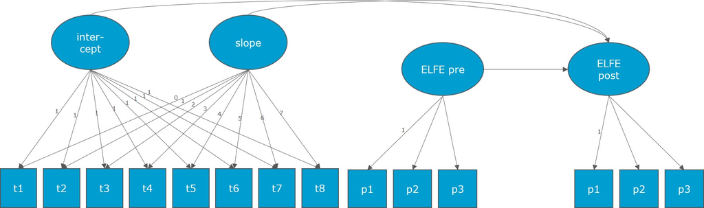

Validity of Change Measurement Model 2

Implement Predictive Validity Model: We are interested in the influence of the latent intercept and slope estimated over all quop scores (testing points 1 to 8) on elfe post scores incremental to elfe pre scores.

```r
ch_val_model_2 <- '
                      ##LATENT CHANGE MODEL: ELFE
                      #LV for elfe pre and post
                      #Same loadings for 2nd/3rd parcel between time points
                      #Loadings for the 1st parcel per time point are restricted to 1 by default for
                      #model identification
                      ELFE_pre =~ e1_p1 + a*e1_p2 + b*e1_p3
                      ELFE_post =~ e2_p1 + a*e2_p2 + b*e2_p3

                      #allow indicator-specific covariances between the same parcel over measurements
                      #(errors covary)
                      e1_p1 ~~ e2_p1
                      e1_p2 ~~ e2_p2
                      e1_p3 ~~ e2_p3

                      ##LATENT GROWTH MODEL: QUOP
                      #LV intercept on which all indicators loadings are 1
                      inter =~ 1*q1 + 1*q2 + 1*q3 + 1*q4
                                 + 1*q5 + 1*q6 + 1*q7 + 1*q8

                      #LV slope with linearly increasing loadings
                            slope =~ 0*q1 + 1*q2 + 2*q3 + 3*q4
                                   + 4*q5 + 5*q6 + 6*q7 + 7*q8

                      #Predictive Validity
                      ELFE_post ~ ELFE_pre + inter + slope
                     '
```

Estimate Model per Scale.

**Word**

```r
pr_val_wort.fit <- cfa(ch_val_model_2, data=ch_val_wort, estimator="mlr", missing="fiml", cluster="class")
#fit measures
fit_msrs_w_2 <- fit_msrs(pr_val_wort.fit)
(fit_msrs_w_2_f <- formattable(fit_msrs_w_2))
```

| RMSEA | SRMR | CFI | TLI |
| --- | --- | --- | --- |
| 0.02 | 0.028 | 0.998 | 0.998 |

```r
#parameter estimates
lhs <- c("ELFE_post", "ELFE_post", "ELFE_post")
op <- c("~","~", "~")
rhs <- c("ELFE_pre", "inter", "slope")
estimates_w_2 <- data.frame(t(mapply(function(lhs,op,rhs){extract_res(pr_val_wort.fit, lhs,op,rhs)}, lhs, op, rhs)))
row.names(estimates_w_2) <- paste0(lhs,op,rhs)
(estimates_w_2_f <- formattable(estimates_w_2))
```

|  | Estimate | SE | P.value |
| --- | --- | --- | --- |
| ELFE_post~ELFE_pre | 0.49 | 0.08 | 0.0000 |
| ELFE_post~inter | 0.47 | 0.08 | 0.0000 |
| ELFE_post~slope | 0.22 | 0.08 | 0.0057 |

```r
#summary(pr_val_wort.fit, std=T, fit.measures=T)
```

**Sentence**

```r
pr_val_satz.fit <- cfa(ch_val_model_2, data=ch_val_satz, estimator="mlr", missing="fiml", cluster="class")
#fit measures
fit_msrs_s_2 <- fit_msrs(pr_val_satz.fit)
(fit_msrs_s_2_f <- formattable(fit_msrs_s_2))
```

| RMSEA | SRMR | CFI | TLI |
| --- | --- | --- | --- |
| 0.031 | 0.028 | 0.996 | 0.995 |

```r
#parameter estimates
estimates_s_2 <- data.frame(t(mapply(function(lhs,op,rhs){extract_res(pr_val_satz.fit, lhs,op,rhs)}, lhs, op, rhs)))
row.names(estimates_s_2) <- paste0(lhs,op,rhs)
(estimates_s_2_f <- formattable(estimates_s_2))
```

|  | Estimate | SE | P.value |
| --- | --- | --- | --- |
| ELFE_post~ELFE_pre | 0.64 | 0.09 | 0 |
| ELFE_post~inter | 0.37 | 0.08 | 0 |
| ELFE_post~slope | 0.31 | 0.05 | 0 |

```r
#summary(pr_val_satz.fit, std=T, fit.measures=T)
```

**Text**

```r
pr_val_text.fit <- cfa(ch_val_model_2, data=ch_val_text, estimator="mlr", missing="fiml", cluster="class")
#fit measures
fit_msrs_t_2 <- fit_msrs(pr_val_text.fit)
(fit_msrs_t_2_f <- formattable(fit_msrs_t_2))
```

| RMSEA | SRMR | CFI | TLI |
| --- | --- | --- | --- |
| 0.03 | 0.035 | 0.994 | 0.993 |

```r
#parameter estimates
estimates_t_2 <- data.frame(t(mapply(function(lhs,op,rhs){extract_res(pr_val_text.fit, lhs,op,rhs)}, lhs, op, rhs)))
row.names(estimates_t_2) <- paste0(lhs,op,rhs)
(estimates_t_2_f <- formattable(estimates_t_2))
```

|  | Estimate | SE | P.value |
| --- | --- | --- | --- |
| ELFE_post~ELFE_pre | 0.46 | 0.07 | 0 |
| ELFE_post~inter | 0.43 | 0.08 | 0 |
| ELFE_post~slope | 0.31 | 0.08 | 0 |

```r
#summary(pr_val_text.fit, std=T, fit.measures=T)
```

# 11 Post-Hoc Analysis

To investigate why quop slope and ELFE prepost difference were not related on word level,reanalyze the word level data based on frequent word items only. This post-hoc analysis can be found in this notebook. A new notebook is created, as most of the preprocessing steps need to be redone with the items under consideration.